# Machine Learning Course Project

John Tribbia

June 7, 2017

#### I. Synopsis

##### This analysis uses data from accelerometers on the belt, forearm, arm, and dumbell of 6 participants and strives to quantify how well they perform barbell lifts in 5 different ways.The data for this project come from the following source: http://groupware.les.inf.puc-rio.br/har.

##### The basic goal of this analysis is to predict the manner in which the participants did the exercise. I use the “classe” variable on which to make predictions. The R scripts and correpsonding output below will: 1. load and preprocess data, 2. describe how the model was built, 3. describe cross validation techniques employed, and 4. use the prediction model to make predictions on 20 different test cases.

#### II. Data Loading and Preprocessing the Data

##### 1. Loading Packages and Data

```r
# a. Load packages
list.of.packages <- c("dplyr","ggplot2","gridExtra","stringr","caret","randomForest","rpart","rpart.plot")
new.packages <- list.of.packages[!(list.of.packages %in% installed.packages()[,"Package"])]
if(length(new.packages)) install.packages(new.packages)

library(dplyr,warn.conflicts = FALSE, quietly=TRUE)
library(ggplot2,warn.conflicts = FALSE, quietly=TRUE)
library(gridExtra,warn.conflicts = FALSE, quietly=TRUE)
library(stringr,warn.conflicts = FALSE, quietly=TRUE)
library(caret,warn.conflicts = FALSE, quietly=TRUE)
library(randomForest,warn.conflicts = FALSE, quietly=TRUE)
library(rpart,warn.conflicts = FALSE, quietly=TRUE)
library(rpart.plot,warn.conflicts = FALSE, quietly=TRUE)

# b. Set working directory where you want to store the unzipped datafiles
setwd(wd)

# c. Unzip and Extract data from url
train_file <- "https://d396qusza40orc.cloudfront.net/predmachlearn/pml-training.csv"
download.file(train_file, destfile = "pml-training.csv", mode = "wb") # download file from url in directory
df_train <- tbl_df(read.csv("./pml-training.csv",na.strings=c("NA","#DIV/0!", ""))) # import data to workspace as tbl_df in dplyr

validate_file <- "https://d396qusza40orc.cloudfront.net/predmachlearn/pml-testing.csv"
download.file(validate_file, destfile = "pml-testing.csv", mode = "wb") # download file from url in directory
df_validate <- tbl_df(read.csv("./pml-testing.csv",na.strings=c("NA","#DIV/0!", ""))) # import data to workspace as tbl_df in dplyr
```

##### 2. Inspect the Data

```r
# d. inspect data
df_train
head(df_train)

df_validate
summary(df_validate)
```

##### 3. Preprocess the Data

```r
# remove columns containing *only* NA values
# select relevant columns to be used in analysis
df_train1 <- df_train %>%
  select_if(colSums(is.na(.)) == 0) %>%
  select(roll_belt:classe)

## split train data into training and test sets with a 75% partition to train:test
set.seed(999)
train_cut <- createDataPartition(y=df_train1$classe, p=0.75, list=FALSE)
df_train_final <- df_train1[train_cut, ]
df_test_final <- df_train1[-train_cut, ]
```

#### III. Model Building

##### 1. What is the frequency distribution of the classe variable?

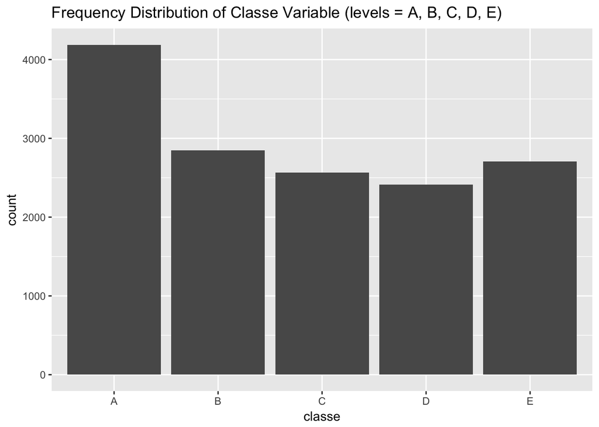

```r
# a. bar plot classe variable on the training dataset
qplot(classe, data = df_train_final, geom = "bar", main = "Frequency Distribution of Classe Variable (levels = A, B, C, D, E)")
```

##### Summary: The figure above shows the frequency distribution of the classe variable on the training dataset. Classe A occurs most frequently and level D least frequently.